# Problem Set 7 | MACS 301

Julian McClellan

February 27, 2017

# Part 1: Sexy Joe Biden

### 1. Estimate the training MSE of the model using the traditional approach.

|  | *Dependent variable:* |
| --- | --- |
|  | biden |
| female | 4.103*** |
|  | (0.948) |
| age | 0.048* |
|  | (0.028) |
| educ | -0.345* |
|  | (0.195) |
| dem | 15.424*** |
|  | (1.068) |
| rep | -15.850*** |
|  | (1.311) |
| Constant | 58.811*** |
|  | (3.124) |
| Observations | 1,807 |
| R<sup>2</sup> | 0.282 |
| Adjusted R<sup>2</sup> | 0.280 |
| Residual Std. Error | 19.914 (df = 1801) |
| F Statistic | 141.150*** (df = 5; 1801) |
| *Note:* | p<0.1; p<0.05; p<0.01 |

The mean squared error of a linear model using all of the predictors, and calculated on all of the (training) data is 395.2701693.

### 2. Estimate the test MSE of the model using the validation set approach.

The mean squared error of a linear model using all of the predictors, and calculated on only the test set (30% of the data) is 428.281. This value is 33.011 (8.35%) larger than the MSE calculated using only the training data. We expect the two MSE’s to be different

### 3. Repeat the validation set approach 100 times, using 100 different splits of the observations into a training set and a validation set. Comment on the results obtained.

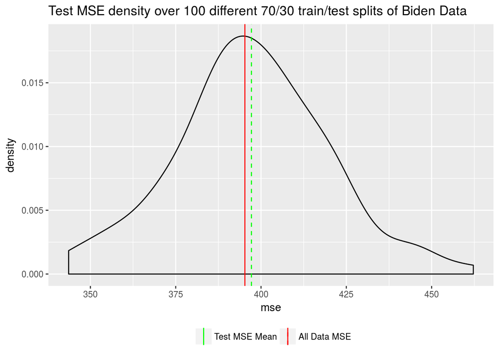

As we can see from the above density graph, thanks to the Central Limit Theorem (each Test MSE is independent!), the distribution of our Test MSE’s is centered about the true mean of the distribution: the MSE for the whole dataset. Of course, since we have a distribution, there is some variability as to what the Test MSE actually is. If we were to select a model based on the test MSE of a certain validation set (1 train 1 test) split of the data, that model selected has a chance of differing from a model selected using the same procedure, but a different validation set split.

### 4. Estimate the test MSE of the model using the leave-one-out cross-validation (LOOCV) approach. Comment on the results obtained.

The estimated test MSE of the model using the LOOCV approach is: 397.9555046. This is only slightly above the training MSE of the model (395.2701693) we obtained when calculated against the entire dataset.

### 5. Estimate the test MSE of the model using the 10-fold cross-validation approach. Comment on the results obtained.

The test MSE of the model using the 10-fold cross-validation approach is 398.2001783. This is a bit higher than the full dataset mse of 395.2701693.

### 6. Repeat the 10-fold cross-validation approach 100 times, using 100 different splits of the observations into 10-folds. Comment on the results obtained.

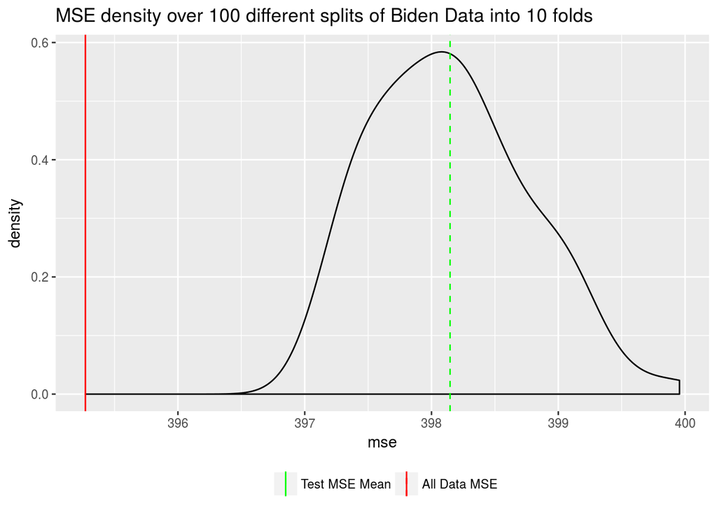

### 7. Compare the estimated parameters and standard errors from the original model in step 1 (the model estimated using all of the available data) to parameters and standard errors estimated using the bootstrap (n = 1000).

```
## [1] "The bootstrap coefficients and standard errors:"
```

```
## # A tibble: 6 × 3
##          term     est.boot    se.boot
##         <chr>        <dbl>      <dbl>
## 1         age   0.04823989 0.02865773
## 2         dem  15.42824956 1.11481695
## 3        educ  -0.34084352 0.19415366
## 4      female   4.13559120 0.96547884
## 5 (Intercept)  58.71811467 3.05035358
## 6         rep -15.87780010 1.40401526
```

```
##                 Estimate Std. Error    t value     Pr(>|t|)
## (Intercept)  58.81125899  3.1244366  18.822996 2.694143e-72
## female        4.10323009  0.9482286   4.327258 1.592601e-05
## age           0.04825892  0.0282474   1.708438 8.772744e-02
## educ         -0.34533479  0.1947796  -1.772952 7.640571e-02
## dem          15.42425563  1.0680327  14.441745 8.144928e-45
## rep         -15.84950614  1.3113624 -12.086290 2.157309e-32
```

The bootstrap standard errors for `female`, `age`, `dem`, and `rep` are larger than the standard errors in the original model in step 1, while the bootstrap standard errors for `educ` and the intercept are smaller than the standard errors in the original model.

In general, this confirms what we expect of the bootstrap standard errors, that they are larger (for the most part) than the non-bootstrap standard errors because they do not rely on distributional assumptions.

The parameters between the two models are essentially the same.

# 2. College (bivariate)

### (1) Simple Linear Model: `Outstate` on `Room.Board`

The first thing that we should check is whether or not a linear relationship is appropriate. Let’s begin by simply plotting `Outstate` against `Room.Board`

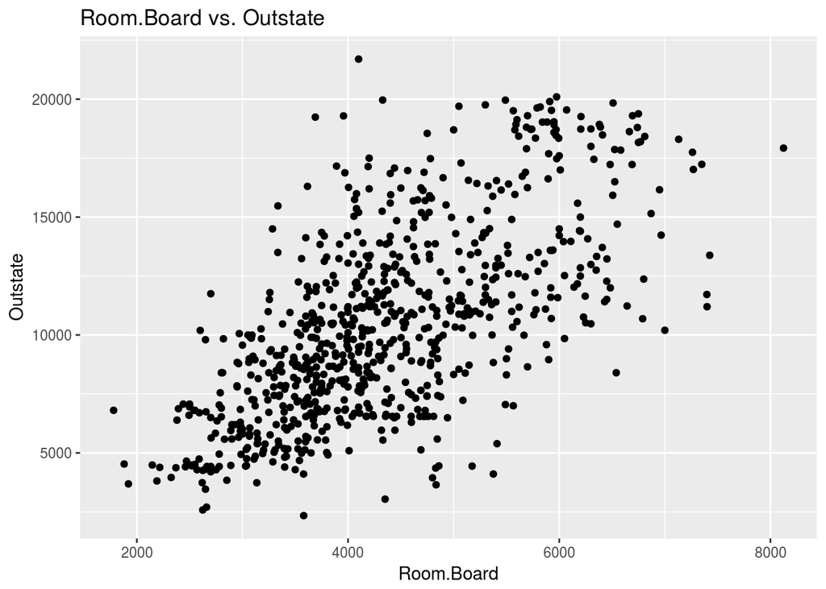

Looking at this graph, a linear relationship, though not a perfect fit, seems to be appropriate to model the relationship between `Outstate` and `Room.Board`. Let’s go ahead and look at the predicted values and residuals plot when a linear model is applied. If the residuals are not correlated with the fitted values, then a linear model is indeed appropriate.

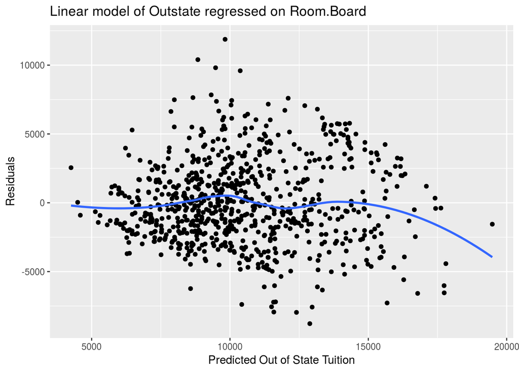

Looking at the smooth fit line on this graph, it does indeed appear that the residuals are not correlated with the predicted values. Perhaps there seems to be a bit of a negative correlation towards the higher predicted out of state tuition, but the overall trend is clear.

However, it is still possible that higher degree polynomials might provide better results. Thus, we will use k-fold cross validation (`k = 10`) to determine the ideal polynomial.

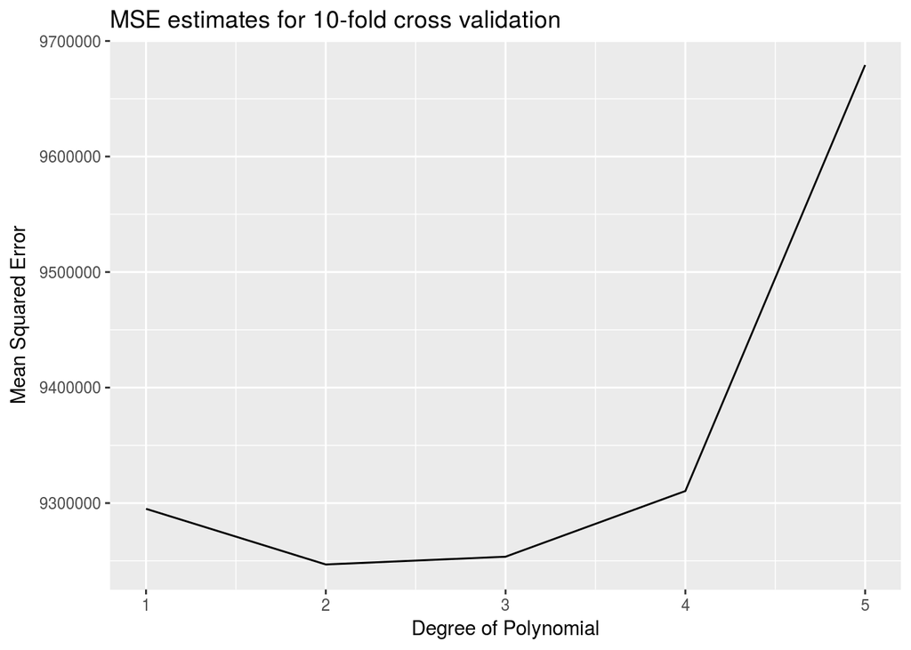

Looking at this graph of MSE, we see that a 2nd degree polynomialprovides the lowest MSE under 10-fold cross validation. Thus, we will create a 2nd degree polynomial linear model and report/graph the results.

**Outstate on Room.Board | Linear 2nd degree polynomial**

|  | *Dependent variable:* |
| --- | --- |
|  | Outstate |
| poly(Room.Board, 2)1 | 73,321.380*** |
|  | (3,037.357) |
| poly(Room.Board, 2)2 | -6,534.815** |
|  | (3,037.357) |
| Constant | 10,440.670*** |
|  | (108.965) |
| Observations | 777 |
| R<sup>2</sup> | 0.431 |
| Adjusted R<sup>2</sup> | 0.430 |
| Residual Std. Error | 3,037.357 (df = 774) |
| F Statistic | 293.681*** (df = 2; 774) |
| *Note:* | p<0.1; p<0.05; p<0.01 |

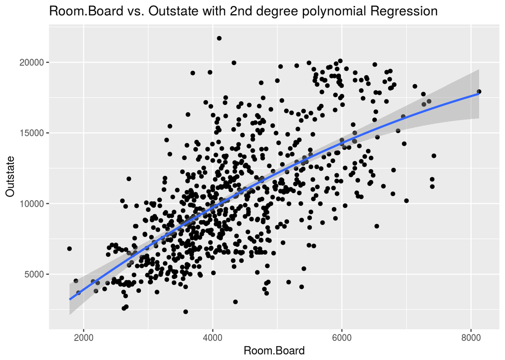

Let’s also do a final graph of the predicted out of state tuition versus the residuals.

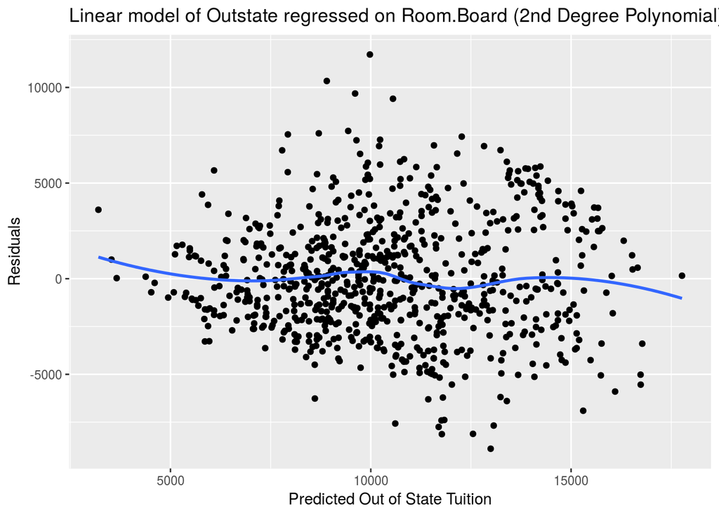

As desired, the residuals do not apear to be correlated with predicted out of state tuition.

### (2) Simple Linear Model: `Outstate` on `Grad.Rate`

The first thing that we should check is whether or not a linear relationship is appropriate. Let’s begin by simply plotting `Outstate` against `Grad.Rate`

[figure not shown]

Looking at this graph, a linear relationship, seems to be appropriate to model the relationship between `Outstate` and `Grad.Rate`. However, looking closely at the graph, we see a graduation rate of over 100%. This observation seems to be erroneous so we will have it removed in the proceeding work done to explore the bivariate relationship between `Outstate` and `Grad.Rate`.

Let’s go ahead and look at the predicted values and residuals plot when a linear model is applied. If the residuals are not correlated with the fitted values, then a linear model is indeed appropriate.

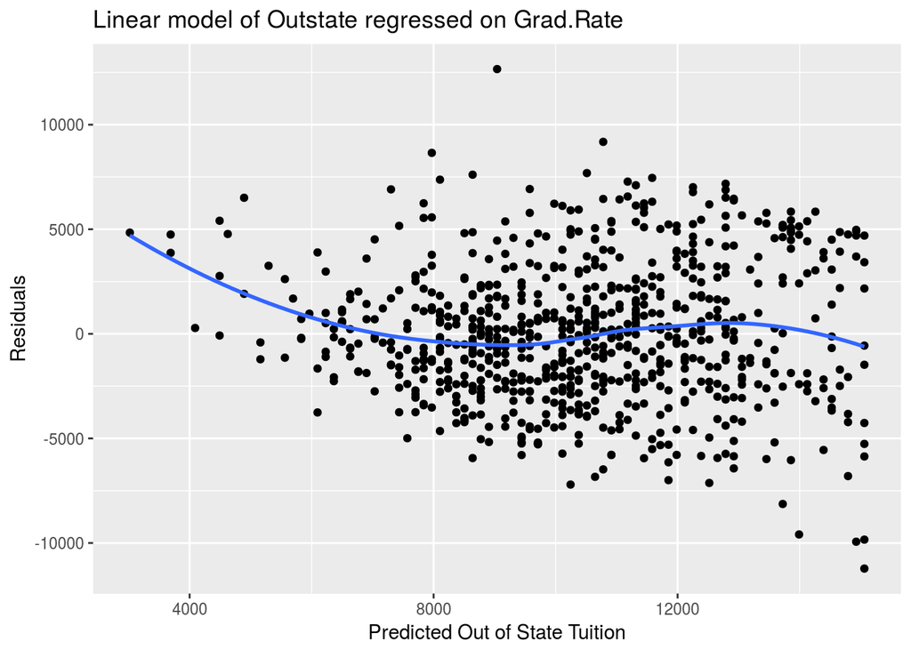

Looking at the smooth fit line on this graph, with the exception of the earlier predicted Out of State Tuition, it does indeed appear that the residuals are not correlated with the predicted values. However, in order to deal with the correlation between the residuals and predictd out of state tuition in for lower predicted of state tuition values, we should consider polynomial regression.

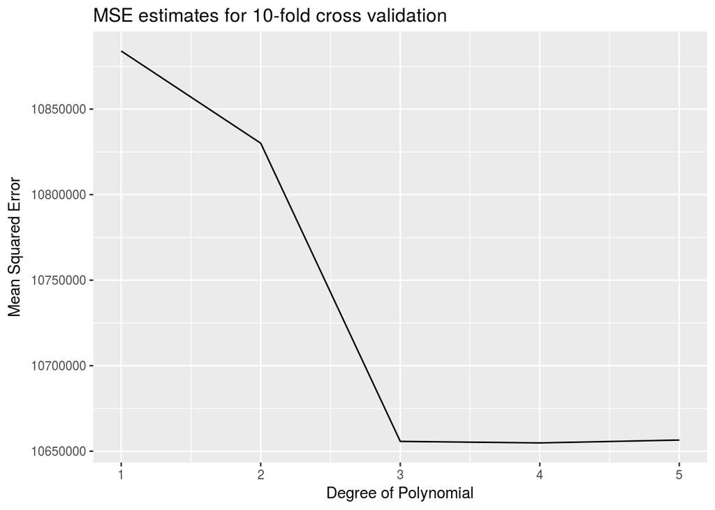

[output not shown]

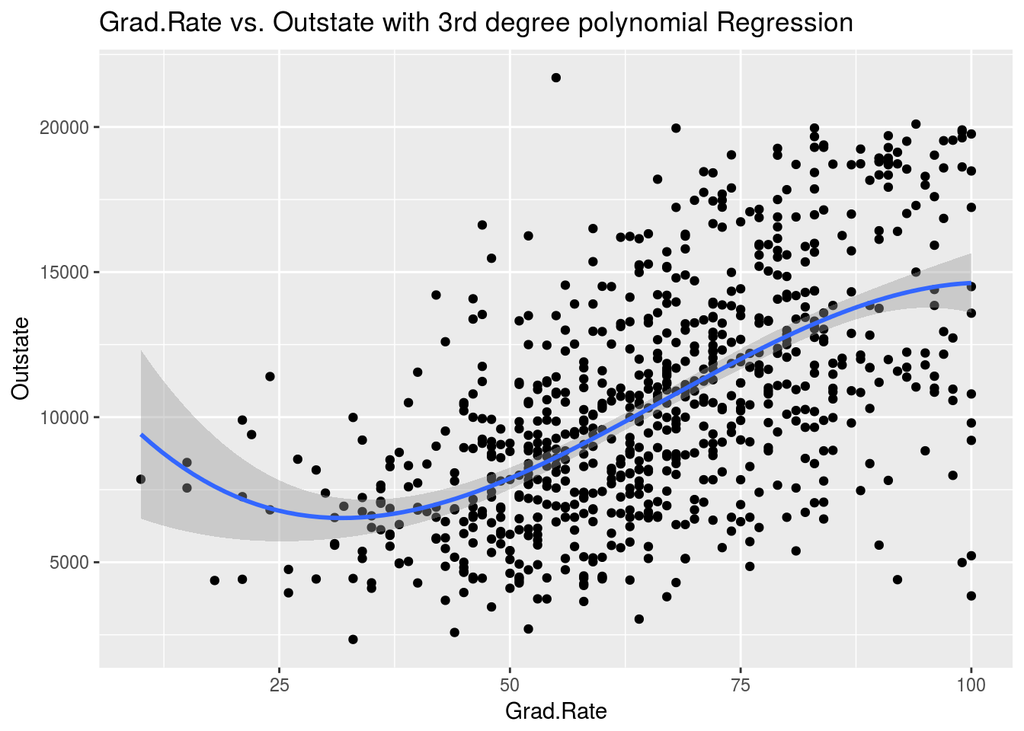

Let’s also do a final graph of the predicted out of state tuition versus the residuals.

[figure not shown]

As desired, the residuals do not apear to be correlated with predicted out of state tuition.

### (3) Simple Linear Model: `Outstate` on `Expend`

The first thing that we should check is whether or not a linear relationship is appropriate. Let’s begin by simply plotting `Outstate` against `Expend`

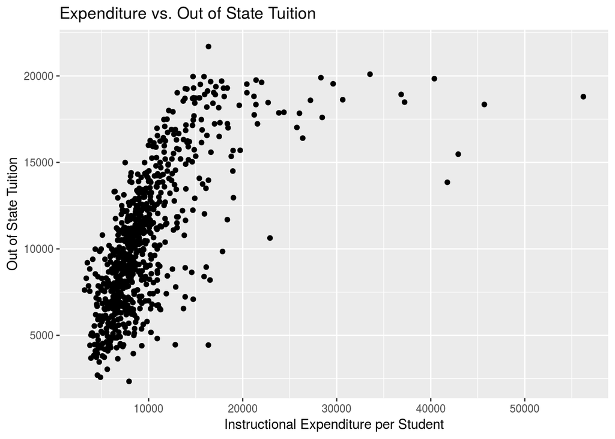

The relationship between `Outstate` and `Expend` does not appear to be linear, but rather logarithmic. Accordingly, we will regress `Outstate` on the logarithm of X.

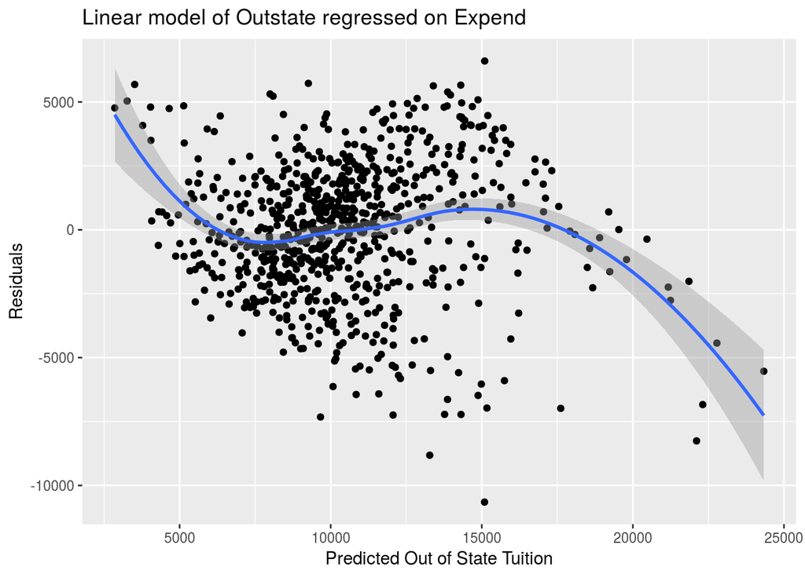

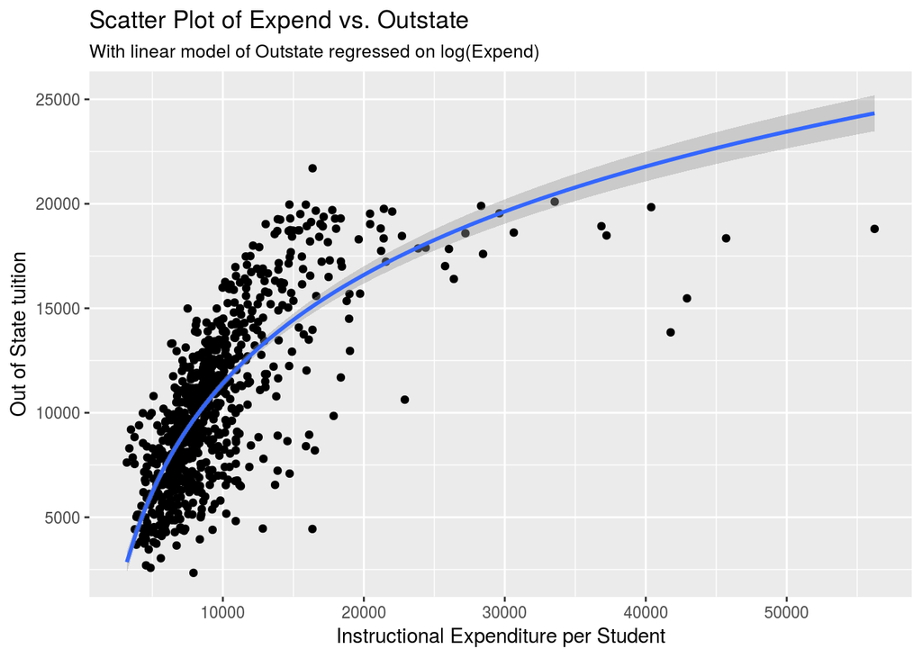

How do we know that a linear model of `Outstate` regressed on `log(Expend)` is better than a linear model regressed on `Expend`? Let’s use 10-fold cross validation to compare the log MSE vs the untransformed MSE with several polynomial degrees.

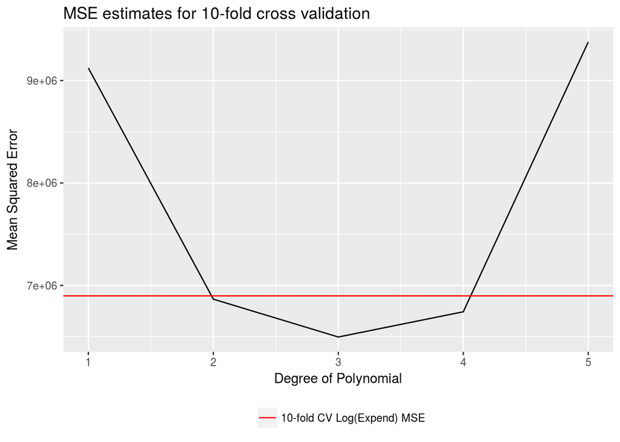

As we can see form the above graph, the 10-fold MSE is actually lower for a third degree polynomial of `Expend` than it is for the `log(Expend)`. However, paying attention to the scale here, the difference is actually not all that large. Because interpretation is more tractable for a regression on `log(Expend)` we will elect to use that model. Let’s report/graph the results then.

|  | *Dependent variable:* |
| --- | --- |
|  | Outstate |
| log(Expend) | 7,482.150*** |
|  | (229.915) |
| Constant | -57,502.040*** |
|  | (2,089.888) |
| Observations | 777 |
| R<sup>2</sup> | 0.577 |
| Adjusted R<sup>2</sup> | 0.577 |
| Residual Std. Error | 2,616.838 (df = 775) |
| F Statistic | 1,059.051*** (df = 1; 775) |
| *Note:* | p<0.1; p<0.05; p<0.01 |

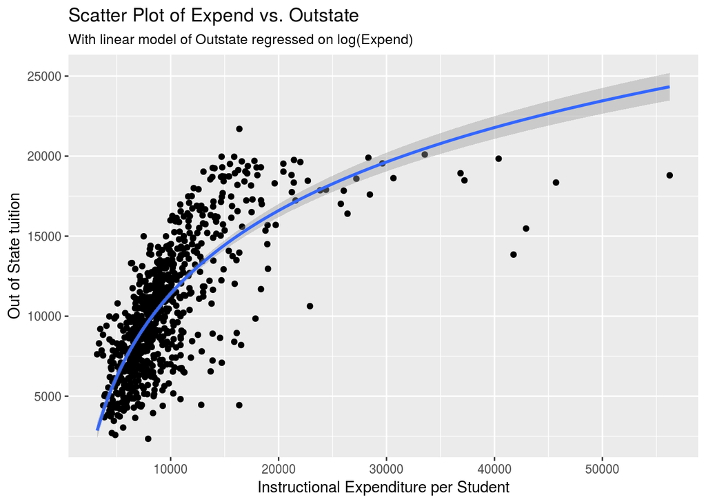

A note for the interpretation of the coefficient of `log(Expend)`. We can say that a 1% increase in Instructional Expenditure per student results in a `coefficient(Expend) / 100` increase in Out of State tuition. In this case, we can say that a 1% increase in `Expend` results in a 74.8214987 increase in `Outstate` (Out of state tuition).

# Part 3. College (GAM)

### 1. Split the data into a training set and a test set.

```r
set.seed(69)
college_split <- resample_partition(df.college, c(test = .3, train = .7))
```

### 2. Estimate an OLS model on the training data, using out-of-state tuition (Outstate) as the response variable and the other six variables as the predictors. Interpret the results and explain your findings, using appropriate techniques (tables, graphs, statistical tests, etc.).

**OLS**

|  | *Dependent variable:* |
| --- | --- |
|  | Outstate |
| PrivateYes | 2,706.981*** |
|  | (247.488) |
| Room.Board | 1.007*** |
|  | (0.099) |
| PhD | 33.459*** |
|  | (6.704) |
| perc.alumni | 50.220*** |
|  | (9.075) |
| Expend | 0.200*** |
|  | (0.020) |
| Grad.Rate | 30.333*** |
|  | (6.181) |
| Constant | -3,480.289*** |
|  | (516.787) |
| Observations | 544 |
| R<sup>2</sup> | 0.741 |
| Adjusted R<sup>2</sup> | 0.738 |
| Residual Std. Error | 2,047.060 (df = 537) |
| F Statistic | 255.551*** (df = 6; 537) |
| *Note:* | p<0.1; p<0.05; p<0.01 |

As we can see from the table, all 6 predictor variables are significant even at the $\alpha = .01$ level. Let’s take a quick look at the residuals versus predicted values plot.

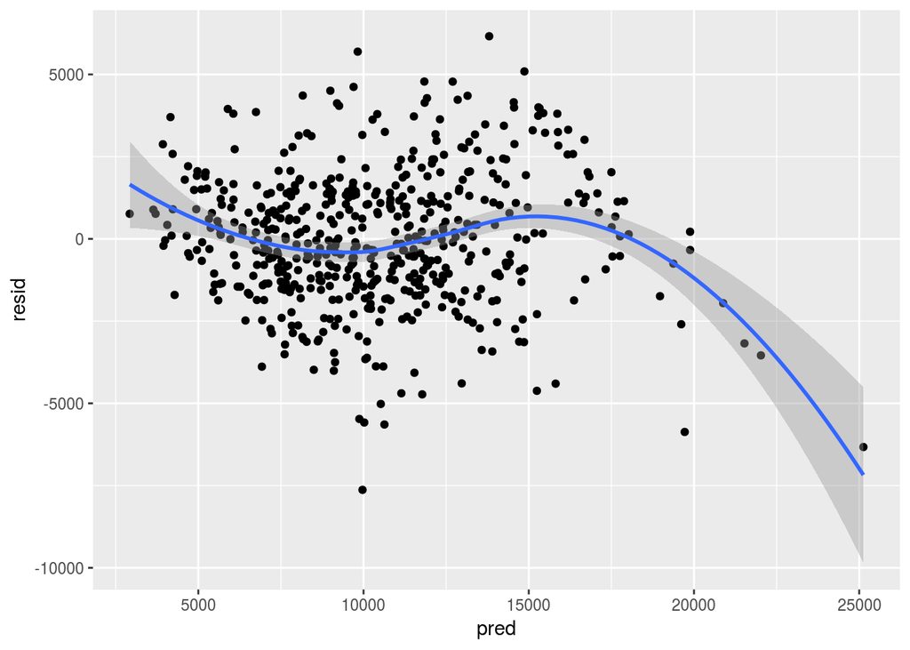

For the most part, with the exception of the upper tail, the residuals seem uncorrelated with the predicted values, as desired.

### 3. Estimate a GAM on the training data, using out-of-state tuition (Outstate) as the response variable and the other six variables as the predictors. You can select any non-linear method (or linear) presented in the readings or in-class to fit each variable. Plot the results, and explain your findings. Interpret the results and explain your findings, using appropriate techniques (tables, graphs, statistical tests, etc.).

We will use a GAM model that regresses `Outstate` on the binary predictor Private (no alterations to this), a 2nd degree polynomial of `Room.Board` (opted for in part 2), local regressions for `PhD` and `perc.alumni`, the `log(Expend)` (from part 2 again), and a third degree polynomial for `Grad.Rate` (opted for in part 2).

```
##
## Call: gam(formula = Outstate ~ Private + poly(Room.Board, 2) + lo(PhD) +
##     lo(perc.alumni) + log(Expend) + poly(Grad.Rate, 3), data = college_split$train)
## Deviance Residuals:
##      Min       1Q   Median       3Q      Max
## -7210.93 -1153.12   -61.96  1251.31  5302.77
##
## (Dispersion Parameter for gaussian family taken to be 3791564)
##
##     Null Deviance: 8675527220 on 543 degrees of freedom
## Residual Deviance: 2005539037 on 528.9478 degrees of freedom
## AIC: 9801.314
##
## Number of Local Scoring Iterations: 2
##
## Anova for Parametric Effects
##                         Df     Sum Sq    Mean Sq F value    Pr(>F)
## Private               1.00 2507818119 2507818119 661.421 < 2.2e-16 ***
## poly(Room.Board, 2)   2.00 2133611957 1066805979 281.363 < 2.2e-16 ***
## lo(PhD)               1.00  763498795  763498795 201.368 < 2.2e-16 ***
## lo(perc.alumni)       1.00  370687658  370687658  97.766 < 2.2e-16 ***
## log(Expend)           1.00  516437008  516437008 136.207 < 2.2e-16 ***
## poly(Grad.Rate, 3)    3.00  131294645   43764882  11.543 2.438e-07 ***
## Residuals           528.95 2005539037    3791564
## ---
## Signif. codes:  0 '***' 0.001 '**' 0.01 '*' 0.05 '.' 0.1 ' ' 1
##
## Anova for Nonparametric Effects
##                     Npar Df  Npar F   Pr(F)
## (Intercept)
## Private
## poly(Room.Board, 2)
## lo(PhD)                 2.7 2.95987 0.03738 *
## lo(perc.alumni)         2.4 0.21728 0.84033
## log(Expend)
## poly(Grad.Rate, 3)
## ---
## Signif. codes:  0 '***' 0.001 '**' 0.01 '*' 0.05 '.' 0.1 ' ' 1
```

All the predictors have statistically significant (at the `0` level) F-values for parametric effects. This is not too surprising, as our OLS model, in which the assumed a linear parametric effect showed these predictors to be statistically significant as well.

The predictor `PhD` has a statistically significant (at the $\alpha = .05$ level) nonparametric F-value. Meaning, it likely has a nonparametric effect on `Outstate`.

Now let’s graph each effect each predictor has on the response `Outstate`.

#### Effect of `Private`

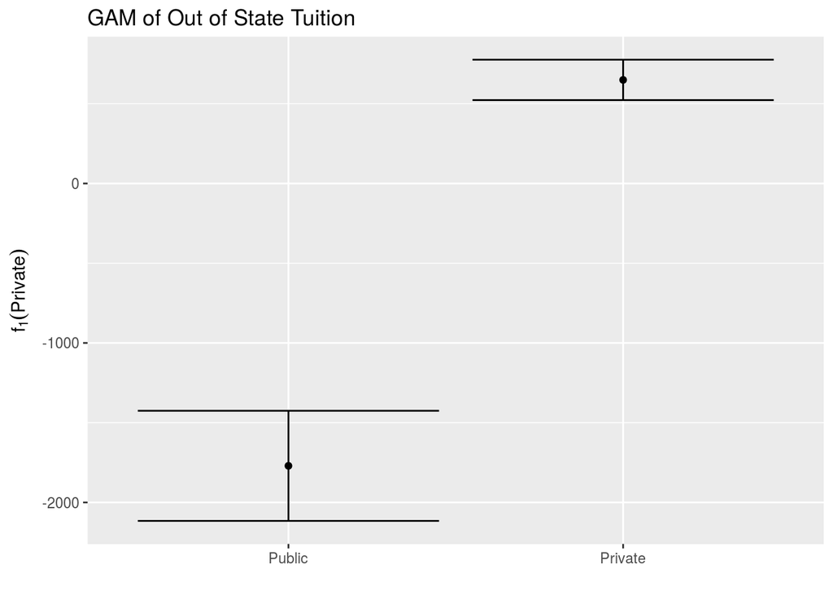

We see the effect of `Private` the binary variable (0 = Public, 1 = Private) is quite distinct across its two values. The effect of a University being public clearly has a negative effect on the response `Outstate`, and the effect of a University being private clearly has a positive effect on `Outstate`, though to a lesser magnitude than a public university.

#### Effect of `Room.Board`

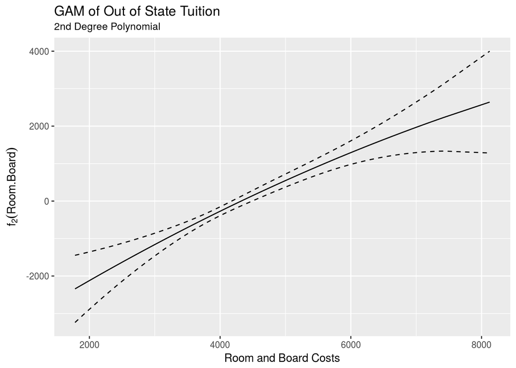

This graph shows that as `Room.Board` increases, `Outstate` consistently incresases.

#### Effect of `PhD`

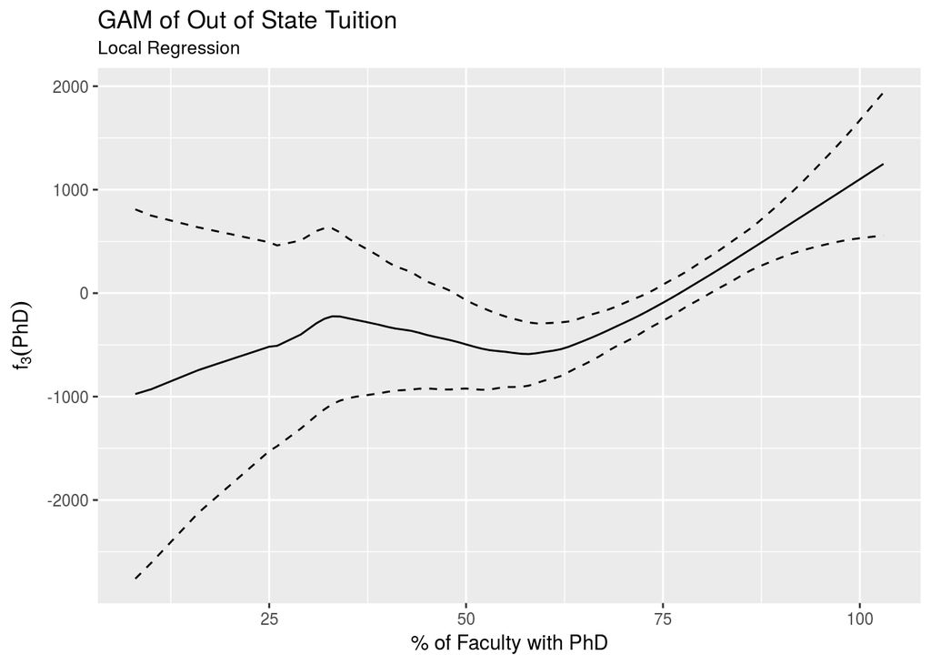

The wide confidence intervals for values of `PhD` below 30% indicate that the effect that increases in `PhD` have on `Outstate` are hard to determine at those levels. However, the confidence interval decreases in size as `PhD` grows larger, eventually showing us that as `PhD` increases, `Outstate` does as well.

#### Effect of `perc.alumni`

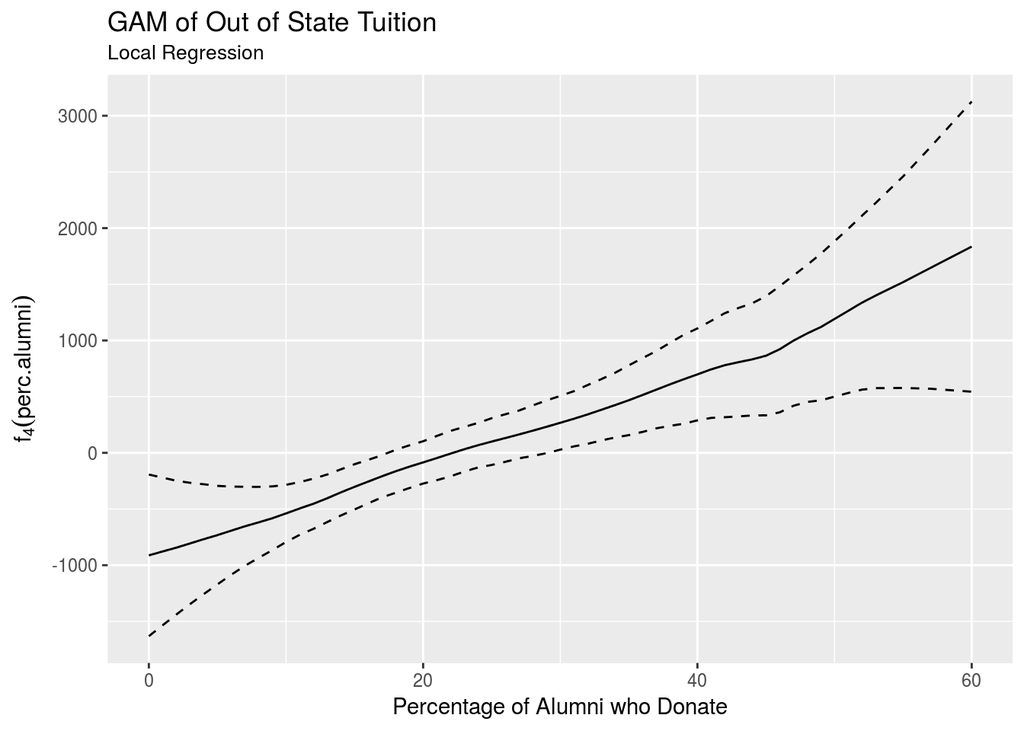

This graph clearly shows that as the percentage of alumni who donate (`perc.alumni`) increases, so does out of state tuition (`Outstate`).

#### Effect of `Expend`

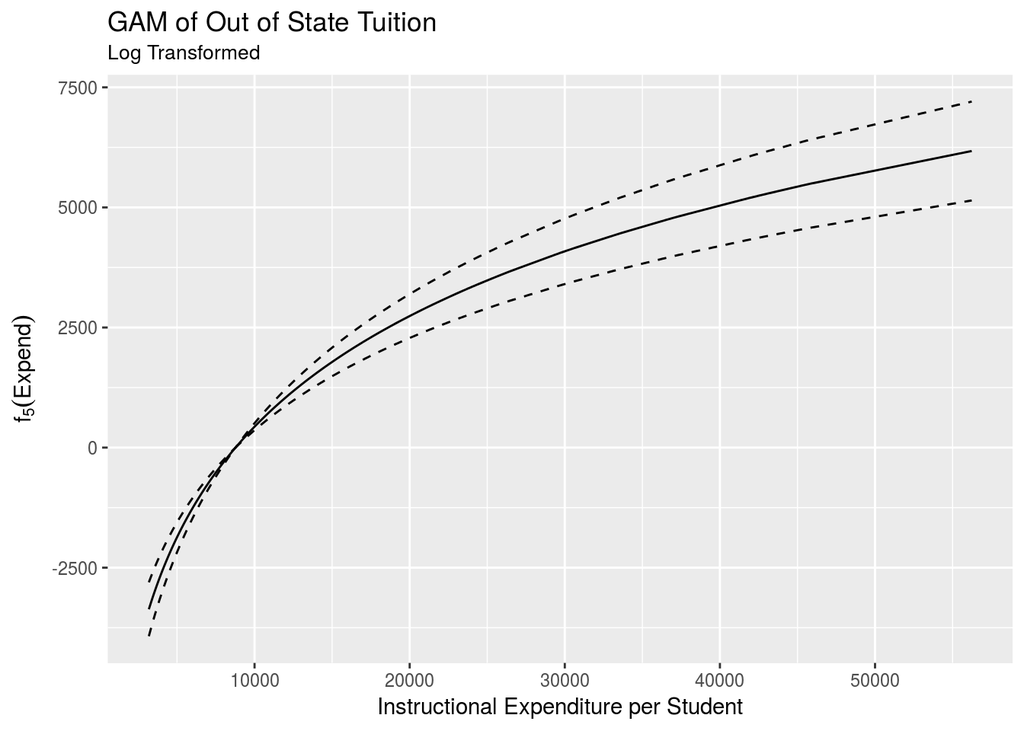

This graph shows that as `Expend` increases at first from its lower values, it increases `Outstate` by more than it does when it increases from its higher values.

#### Effect of `Grad.Rate`

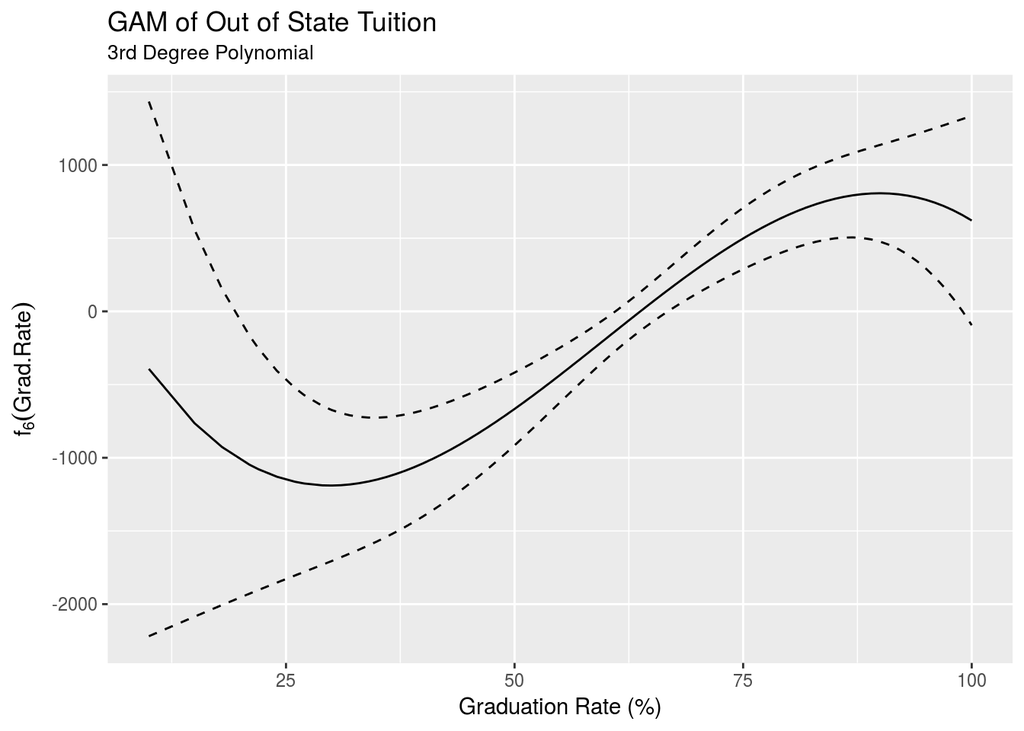

From the lower values of `Grad.Rate`, the effect is hard to determine. As `Grad.Rate` increases, past these values however, it starts to increase `Outstate` until the higher levels of `Grad.Rate` in which the confidence interval opens up again and increases `Grad.Rate` have weaker, harder to determine effects on `Outstate`.

### 4. Use the test set to evaluate the model fit of the estimated OLS and GAM models, and explain the results obtained.

Using the test set to calculate the MSE for both the OLS and the GAM models, we get MSEs of 4.01596910^{6} and 3.445884310^{6} respectively. So it seems that the the GAM model more accurately fits the test data.

### 5. For which variables, if any, is there evidence of a non-linear relationship with the response?

Following 7.8.3 from ISLR we will be computing 5 different ANOVA tests, one for each variable except `Private` which is a qualitative binary variable. Each ANOVA will compare a GAM model utilizing the variable in question in a non-linear fashion, a GAM model utilizing the variable in a linear fashion, and a GAM model not utilizing the variable at all. If one of the models is significant under the ANOVA test, that is evidence that the variable is either not needed, needed with a linear funciton, or needed with a non-linear function.

#### Room and Board

```
## Analysis of Deviance Table
##
## Model 1: Outstate ~ Private + lo(PhD) + lo(perc.alumni) + lo(Expend) +
##     lo(Grad.Rate)
## Model 2: Outstate ~ Private + Room.Board + lo(PhD) + lo(perc.alumni) +
##     lo(Expend) + lo(Grad.Rate)
## Model 3: Outstate ~ Private + lo(Room.Board) + lo(PhD) + lo(perc.alumni) +
##     lo(Expend) + lo(Grad.Rate)
##   Resid. Df Resid. Dev    Df  Deviance  Pr(>Chi)
## 1    526.28 2073914790
## 2    525.28 1848239030 1.000 225675759 7.828e-16 ***
## 3    522.16 1815351664 3.119  32887366   0.02627 *
## ---
## Signif. codes:  0 '***' 0.001 '**' 0.01 '*' 0.05 '.' 0.1 ' ' 1
```

#### PhD

```
## Analysis of Deviance Table
##
## Model 1: Outstate ~ Private + lo(Room.Board) + lo(perc.alumni) + lo(Expend) +
##     lo(Grad.Rate)
## Model 2: Outstate ~ Private + lo(Room.Board) + PhD + lo(perc.alumni) +
##     lo(Expend) + lo(Grad.Rate)
## Model 3: Outstate ~ Private + lo(Room.Board) + lo(PhD) + lo(perc.alumni) +
##     lo(Expend) + lo(Grad.Rate)
##   Resid. Df Resid. Dev     Df Deviance Pr(>Chi)
## 1    525.85 1849755968
## 2    524.85 1828045729 1.0000 21710239  0.01246 *
## 3    522.16 1815351664 2.6808 12694065  0.25426
## ---
## Signif. codes:  0 '***' 0.001 '**' 0.01 '*' 0.05 '.' 0.1 ' ' 1
```

#### Expenditure

```
## Analysis of Deviance Table
##
## Model 1: Outstate ~ Private + lo(Room.Board) + lo(PhD) + lo(perc.alumni) +
##     lo(Grad.Rate)
## Model 2: Outstate ~ Private + lo(Room.Board) + PhD + lo(perc.alumni) +
##     Expend + lo(Grad.Rate)
## Model 3: Outstate ~ Private + lo(Room.Board) + lo(PhD) + lo(perc.alumni) +
##     lo(Expend) + lo(Grad.Rate)
##   Resid. Df Resid. Dev      Df  Deviance  Pr(>Chi)
## 1    527.34 2414732763
## 2    529.02 2179287264 -1.6808 235445499
## 3    522.16 1815351664  6.8590 363935600 < 2.2e-16 ***
## ---
## Signif. codes:  0 '***' 0.001 '**' 0.01 '*' 0.05 '.' 0.1 ' ' 1
```

#### Percent Alumni

```
## Analysis of Deviance Table
##
## Model 1: Outstate ~ Private + lo(Room.Board) + lo(PhD) + lo(Expend) +
##     lo(Grad.Rate)
## Model 2: Outstate ~ Private + lo(Room.Board) + lo(PhD) + perc.alumni +
##     lo(Expend) + lo(Grad.Rate)
## Model 3: Outstate ~ Private + lo(Room.Board) + lo(PhD) + lo(perc.alumni) +
##     lo(Expend) + lo(Grad.Rate)
##   Resid. Df Resid. Dev     Df Deviance  Pr(>Chi)
## 1    525.54 1881346759
## 2    524.54 1821604886 1.0000 59741873 3.393e-05 ***
## 3    522.16 1815351664 2.3714  6253222    0.4889
## ---
## Signif. codes:  0 '***' 0.001 '**' 0.01 '*' 0.05 '.' 0.1 ' ' 1
```

Here we see that the 2nd model (linear `perc.alumni`) is statistically significant at the ‘`0`’ level and that the 3rd model (non-linear `perc.alumni`) is not statistically significant. Thus we have evidence that `perc.alumni` has a linear relationship with the response variable: `Outstate`.

#### Graduation Rate

```
## Analysis of Deviance Table
##
## Model 1: Outstate ~ Private + lo(Room.Board) + lo(PhD) + lo(perc.alumni) +
##     lo(Expend)
## Model 2: Outstate ~ Private + lo(Room.Board) + lo(PhD) + lo(perc.alumni) +
##     lo(Expend) + Grad.Rate
## Model 3: Outstate ~ Private + lo(Room.Board) + lo(PhD) + lo(perc.alumni) +
##     lo(Expend) + lo(Grad.Rate)
##   Resid. Df Resid. Dev     Df  Deviance  Pr(>Chi)
## 1    525.65 1936484870
## 2    524.65 1823833170 1.0000 112651700 1.253e-08 ***
## 3    522.16 1815351664 2.4862   8481506     0.389
## ---
## Signif. codes:  0 '***' 0.001 '**' 0.01 '*' 0.05 '.' 0.1 ' ' 1
```

Here we see that the 2nd model (linear `Grad.Rate`) is statistically significant at the ‘`0`’ level and that the 3rd model (non-linear `Grad.Rate`) is not statistically significiant. Thus we have evidence that `Grad.Rate` has a linear relationship with the response variable: `Outstate`.